# INFLATION ANALYSIS IN THE US ECONOMY

# Time Series Analsis and Forecasting for Electricity Sector

```r
# Filter data for Electricity sector
electricity_data <- group2_long %>%
  filter(TITLE == "Electricity") %>%
  select(YEAR, Value)
```

```r
# Convert the Electricity sector data to a time series
electricity_ts <- ts(electricity_data$Value, start = c(2014, 1), frequency = 12) # Monthly frequency
```

```r
# Fit an ARIMA model to the Electricity data
electricity_arima <- auto.arima(electricity_ts)
summary(electricity_arima)
```

```
## Series: electricity_ts
## ARIMA(0,0,3)(0,1,2)[12]
##
## Coefficients:
##          ma1     ma2     ma3     sma1    sma2
##       0.6425  0.3546  0.3002  -0.1851  0.3316
## s.e.  0.0619  0.0818  0.1047   0.0659  0.0521
##
## sigma^2 = 0.02012:  log likelihood = 125.57
## AIC=-239.13   AICc=-238.75   BIC=-218.56
##
## Training set error measures:
##                      ME      RMSE        MAE         MPE       MAPE      MASE
## Training set 0.00510152 0.1367213 0.08092883 0.005531931 0.08091157 0.6843622
##                    ACF1
## Training set 0.02255984
```

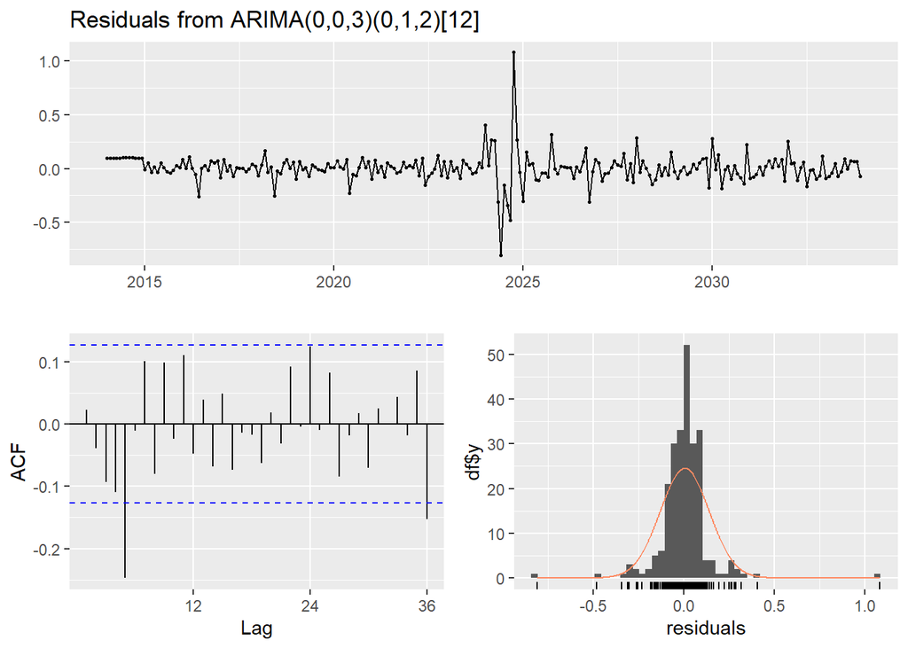

```
##
##  Ljung-Box test
##
## data:  Residuals from ARIMA(0,0,3)(0,1,2)[12]
## Q* = 42.662, df = 19, p-value = 0.001441
##
## Model df: 5.   Total lags used: 24
```

```r
# Perform residual diagnostics
checkresiduals(electricity_arima)
```

# Ljung-Box Test for Electricity

The hypothesis for the Ljung-Box test is:

H₀: The residuals are independent (i.e., there is no autocorrelation in the residuals). H₁: The residuals are not independent (i.e., there is significant autocorrelation)

- Test Statistic, Q∗=42.662: This is the value of the Ljung-Box test statistic.
- Degrees of Freedom (df) = 19: This is calculated based on the number of lags minus the number of estimated parameters in the model.
- p-value = 0.001441: The p-value is below the standard significance level of 0.05

Conclusion:

Model Adequacy:

The presence of autocorrelation indicates that the residuals are not white noise. The ARIMA(0,0,3)(0,1,2)[12] model does not adequately capture all patterns in the data. Further refinement of the model is needed by revisiting AR, MA, or seasonal parameters.